# Applied biostats in R

Abel Torres Espin

Nov 2022

# Introduction

This class is intended to bring everything we have seen until now together by presenting a few illustrative use cases of experiments that will help us to review concepts and perform analysis in R. In addition, we will see some important ideas of performing analysis of experimental data.

## The libraries

We are going to use the following packages, make sure you have them installed!

```r
#install.package(tidyverse)
#install.package(DT)
#install.package(rstatix)

library(tidyverse)
library(DT)
library(rstatix)
library(lme4)
library(lmerTest)
```

# Sleeping pills

Let’s take a look at the first dataset, the `sleep` data that comes in the `{datasets}` package. To check the description of the data we can do:

```r
?sleep
```

## The dataset

**Q: Based on the documentation, what can we say about this study?**

Let’s check some things about the data

```r
class(sleep)
```

```
## [1] "data.frame"
```

```r
dim(sleep)
```

```
## [1] 20  3
```

```r
str(sleep)
```

```
## 'data.frame':    20 obs. of  3 variables:
##  $ extra: num  0.7 -1.6 -0.2 -1.2 -0.1 3.4 3.7 0.8 0 2 ...
##  $ group: Factor w/ 2 levels "1","2": 1 1 1 1 1 1 1 1 1 1 ...
##  $ ID   : Factor w/ 10 levels "1","2","3","4",..: 1 2 3 4 5 6 7 8 9 10 ...
```

```r
sleep
```

```
##    extra group ID
## 1    0.7     1  1
## 2   -1.6     1  2
## 3   -0.2     1  3
## 4   -1.2     1  4
## 5   -0.1     1  5
## 6    3.4     1  6
## 7    3.7     1  7
## 8    0.8     1  8
## 9    0.0     1  9
## 10   2.0     1 10
## 11   1.9     2  1
## 12   0.8     2  2
## 13   1.1     2  3
## 14   0.1     2  4
## 15  -0.1     2  5
## 16   4.4     2  6
## 17   5.5     2  7
## 18   1.6     2  8
## 19   4.6     2  9
## 20   3.4     2 10
```

**Q: What type of design is this?** **Q: What is N and n?**

## Some exploratory look at the data

We can start by doing exploratory data analysis or EDA. This is the process of gaining a first inshight of what the data has to offer.

```
WARNING! Exploratory analyses are descriptive, not inferential. To be able to make inferential statements form the data we need to make use of inferential statistics such has hypothesis testing!
```

EDA is more common in datasets that are messy and/or come from studies that has not be designed, that is, studies that are non-experimental. In those cases, a good EDA is necessary to understand the data structure, potential counfoundings, etc. It is common that if you have designed the experiment well, and collected the data with the analysis in mind, EDA are less necessary. Even then EDA and descriptive statistics can help to spot data entry errors and other potential issues.

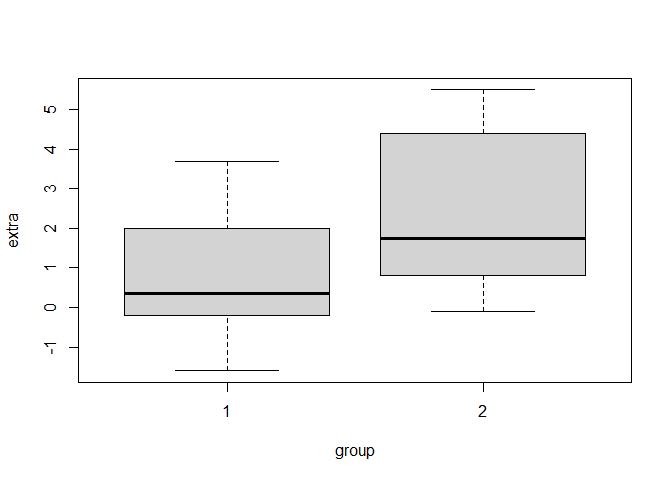

```r
boxplot(extra ~ group, data = sleep) #boxplot with base R
```

## Hypothesis testing

**Q: What hypothesis you think the authors of this dataset wanted to test?** **Q: How would you test for that hypothesis?**

```r
drug_1 <- sleep$extra[sleep$group==1]
drug_2 <- sleep$extra[sleep$group==2]

## effect size as mean difference
mean_diff <- mean(drug_1)-mean(drug_2)

## pooled standard deviation
s1 <- sd(drug_1)
s2 <- sd(drug_2)
n1 <- length(drug_1)
n2 <- length(drug_2)

pooled_sd <- sqrt(((n1-1)*s1^2 + (n2-1)*s2^2) / (n1+n1-2))

t_test <- mean_diff/sqrt(pooled_sd^2 *(1/n1+1/n2))
```

Now using the `t.test()` function!

```r
sleep_test <- t.test(drug_1, drug_2)
sleep_test
```

```
##
##  Welch Two Sample t-test
##
## data:  drug_1 and drug_2
## t = -1.8608, df = 17.776, p-value = 0.07939
## alternative hypothesis: true difference in means is not equal to 0
## 95 percent confidence interval:
##  -3.3654832  0.2054832
## sample estimates:
## mean of x mean of y
##      0.75      2.33
```

**Q: What is the results of the test?** **Q: what is the null hypothesis and the alternative hypothesis in this case?**

### Power the nap!

However, based on the results it seems that there is a potential effect that we are missing. We want to run the experiment again. So we use this data to perform power calculation and help to design the next experiment.

```r
?power.t.test
```

```r
power.t.test(n=NULL, delta = mean_diff, sd = pooled_sd , sig.level = 0.05, power = 0.8)
```

```
##
##      Two-sample t test power calculation
##
##               n = 23.66725
##           delta = 1.58
##              sd = 1.898625
##       sig.level = 0.05
##           power = 0.8
##     alternative = two.sided
##
## NOTE: n is number in *each* group
```

### EXTRA: a little simulation study

Let’s simulate doing the experiment again, for that we are going to perform what is call parametric bootstrapping, that is, taking random draws from the distribution of the first study.

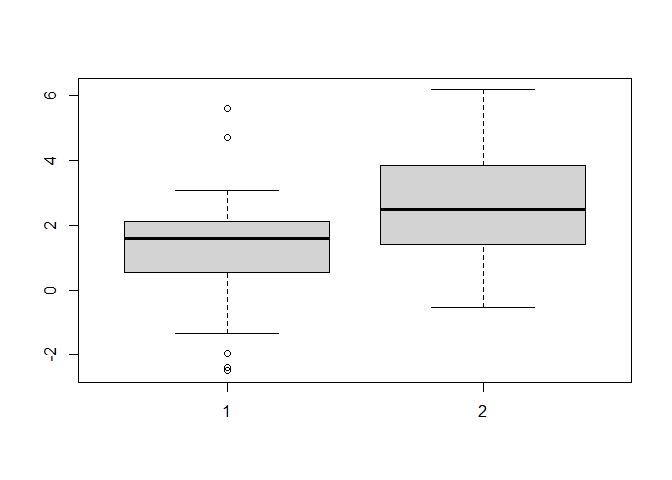

```r
sim_drug_1<- rnorm(24, mean = mean(drug_1), sd = s1)
sim_drug_2<- rnorm(24, mean = mean(drug_2), sd = s2)

boxplot(sim_drug_1, sim_drug_2)
```

```r
t.test(sim_drug_1, sim_drug_2)
```

```
##
##  Welch Two Sample t-test
##
## data:  sim_drug_1 and sim_drug_2
## t = -2.7903, df = 45.588, p-value = 0.007662
## alternative hypothesis: true difference in means is not equal to 0
## 95 percent confidence interval:
##  -2.5653319 -0.4149003
## sample estimates:
## mean of x mean of y
##  1.218364  2.708480
```

**exQ: if perform this experiment 1000 times, how often we expect the p value to be significant?**

```r
results <-vector(length = 1000)

for (i in 1:1000){
  sim_drug_1<- rnorm(24, mean = mean(drug_1), sd = s1)
  sim_drug_2<- rnorm(24, mean = mean(drug_2), sd = s2)

  test<-t.test(sim_drug_1, sim_drug_2)

  results[i] <- test$p.value
}
```

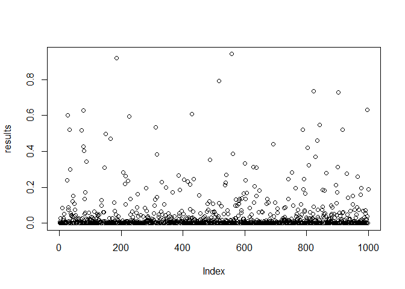

```r
plot(results)
```

```r
mean(results<0.05)*100
```

```
## [1] 81.3
```

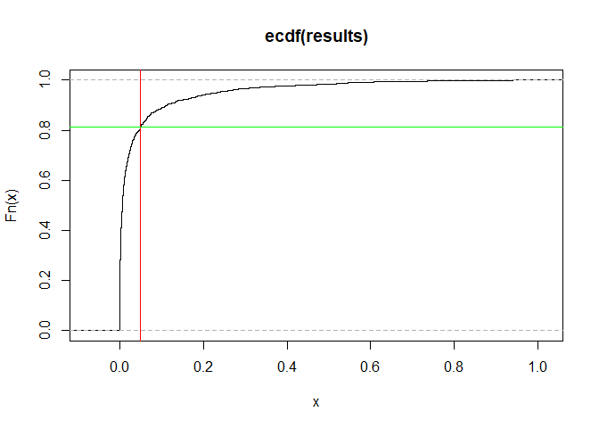

```r
# Empirical distribution
plot(ecdf(results))
abline(v =0.05, col = "red")
abline(h =mean(results<0.05), col = "green")
```

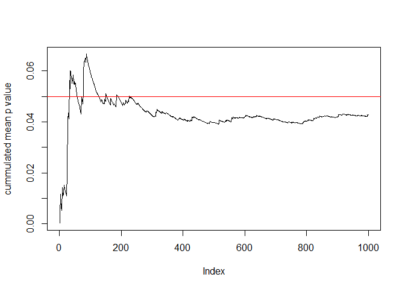

```r
# P value hopping
plot(cummean(results), ylab = "cummulated mean p value", type = "l")
abline(h =0.05, col = "red")
```

```r
## interactive

plot(y = 1, x = 1, ylim = c(0,1), ylab = "p-value", xlim = c(1,100), col = "white")
abline(h = 0.05, col = "red")

for (i in 1:100){
  sim_drug_1<- rnorm(24, mean = mean(drug_1), sd = s1)
  sim_drug_2<- rnorm(24, mean = mean(drug_2), sd = s2)

  test<-t.test(sim_drug_1, sim_drug_2)


  # readline("Enter for next")
  if (test$p.value<0.05){
    color = "green"
  }else{
    color = "orange"
  }
  points(y = test$p.value, x = i, ylim = c(0,0.1),
         ylab = "p-value", col = color)
  Sys.sleep(0.7)
}
```

## Let’s go back to sleep: A second look

Let’s take a second look at this analysis, since we ignored an important fact for illustration!

```r
?sleep
```

```
The group variable name may be misleading about the data: They represent measurements on 10 persons, not in groups.
```

This means that the same subjects are tested for each drug!

**Q: What is our mistake here?**

### A paired analysis

```r
t.test(drug_1, drug_2, paired = T)
```

```
##
##  Paired t-test
##
## data:  drug_1 and drug_2
## t = -4.0621, df = 9, p-value = 0.002833
## alternative hypothesis: true difference in means is not equal to 0
## 95 percent confidence interval:
##  -2.4598858 -0.7001142
## sample estimates:
## mean of the differences
##                   -1.58
```

**Q: What can we conclude with this new result?**

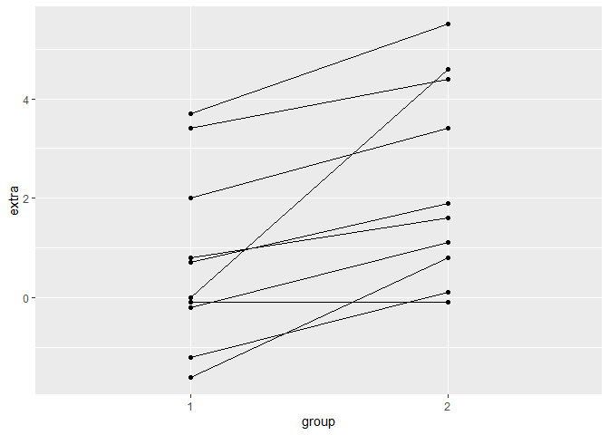

```r
# we will learn more about this in the next class

ggplot(sleep, aes(group,extra, group = ID))+
  geom_point()+
  geom_line()
```

# Animals love to swim

For this analysis we are going to use a dataset that have been deposited at the odc-tbi.org, a data repository for Traumatic Brain Injury (TBI) studies. We have provided the file in CLE, so you should be able to download it and put it in the same folder than this file.

```
DISCLOSURE: Adam, Abel and Russell are part of the ODC-TBI team. This dataset was chosen as it contains particular elements helpful for this class!
```

## The study

The details of the study are published:

```
Clark R. Andersen, Jordan Wolf, Kristofer Jennings, Donald S. Prough, and Bridget E. Hawkins.Journal of Neurotrauma.Feb 2021.435-445.http://doi.org/10.1089/neu.2020.7089
```

The article is open access, so you should be able to read it if you are interested. The work sicks to evaluate different data analysis methods for the Morris water maze (MWM), a learning and memory assessment widely used in behavioral neuroscience and experimental neurology research, including TBI.

MWM is a navigation swim task, where animals are placed in a large circular pool and are required to find an invisible or visible platform by using cues. The time that the animal takes to find the platform is a measure of learning and memory.

## Reading the data

Because this dataset is external to R, we need to read it in first. Datasets in sharing repositories are often companion with metadata, or associated information, such as a data dictionary with the description of each column in the data.

```r
mwm_df <- read.csv("../data/odc-tbi_408.csv")
mwm_dictionary <-read.csv("../data/odc-tbi_408_dict.csv")
```

```r
colnames(mwm_df)
```

```
##  [1] "SubjectIdentifierNumber"    "StudyProtocolName"
##  [3] "AnimalInjuryGroupAssignTyp" "InjModelTyp"
##  [5] "InjModelDevManufName"       "PendulumHeight"
##  [7] "PressurePulseLength"        "AnimalSpeciesTyp"
##  [9] "AnimalSexTyp"               "AnimalStrainGeneModTyp"
## [11] "AnimalAgeVal"               "MWMTestDaysNum"
## [13] "MWMTrialPerDayNum"          "MWMLatencyVal"
## [15] "PlatformFound"
```

```r
mwm_dictionary %>%
  DT::datatable()
```

|  | VariableName | Title | Description | Comments | PermittedValues | DataType | MinimumValue | MaximumValue | Unit_of_Measure |
| --- | --- | --- | --- | --- | --- | --- | --- | --- | --- |
| 1 | SubjectIdentifierNumber | Unique identification number given to the study participant/ subject. | Unique identification number given to the study participant/ subject. | Unique identification number given to the study participant/ subject. | Multiple | Alphanumeric | 1 | 1000000 |  |
| 2 | StudyProtocolName | Name of study protocol | Name of study protocol | Name of study protocol | Multiple | Alphanumeric |  |  |  |
| 3 | AnimalInjuryGroupAssignTyp | Animal subject injury group assignment type | Type of injury group assignment for an animal subject | Type of injury group assignment for an animal subject | Anesthesia controls;Injured;Naive;Other, specify;Sham Injured | Alphanumeric |  |  |  |
| 4 | InjModelTyp | Injury model type description as applied to an animal subject | The type of injury model used for an animal subject | The type of injury model used for an animal subject | Cortical Impact;Weight Drop;Fluid Percussion;Blast;Acceleration;Other, specify | Alphanumeric |  |  |  |
| 5 | InjModelDevManufName | Injury model device manufacturer name | The manufacturer of the device used in the preclinical model of the given injury | The manufacturer of the device used in the preclinical model of the given injury | Multiple | Alphanumeric |  |  |  |
| 6 | PendulumHeight | Pendulum height | Set height of pendulum on fluid percussion injury device, in cm | Set height of pendulum on fluid percussion injury device, in cm | Multiple | Numeric Values | 0 | 30 | cm |
| 7 | PressurePulseLength | Pressure pulse length | Set pulse length of pressure wave in fluid percussion injury device, in ms | Set pulse length of pressure wave in fluid percussion injury device, in ms | Multiple | Numeric Values | 0 | 100 | ms |
| 8 | AnimalSpeciesTyp | Animal species type | Type of animal species being studied | Type of animal species of being studied | Mice;Rats;Pigs | Alphanumeric |  |  |  |
| 9 | AnimalSexTyp | Animal sex type | Type of animal species sex as determined by observation | Type of animal species sex as determined by observation | Male;Female;Other | Alphanumeric |  |  |  |
| 10 | AnimalStrainGeneModTyp | Animal strain/genetic modifications type | Type of strain of animal species, including genetic modification | Type of strain of animal species, including genetic modification | Multiple | Alphanumeric |  |  |  |

[output cut: 5 more lines]